# Homework 07

## Question 2

```r
rep_sample_25 <- nobel_winners_flt %>%
rep_sample_n(size = 25,
             reps = 50) %>%
summarise(prop = n()/nrow(nobel_winners_flt))
rep_sample_25
```

```
## # A tibble: 50 × 2
##    replicate   prop
##        <int>  <dbl>
##  1         1 0.0298
##  2         2 0.0298
##  3         3 0.0298
##  4         4 0.0298
##  5         5 0.0298
##  6         6 0.0298
##  7         7 0.0298
##  8         8 0.0298
##  9         9 0.0298
## 10        10 0.0298
## # ℹ 40 more rows
```

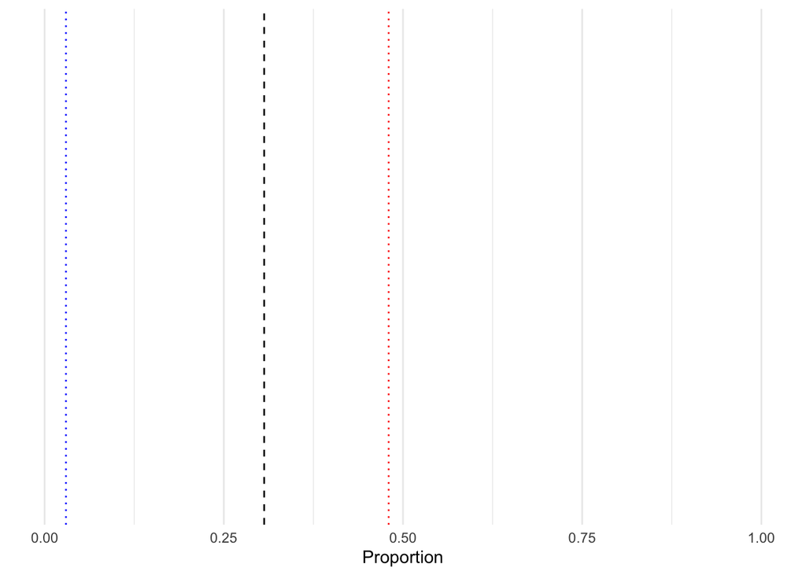

```r
ggplot() +
  coord_cartesian(xlim = c(0,1), ylim = c(0,1)) +
  geom_vline(xintercept = true_prop[2,2][[1]], linetype = "dashed")  +
  geom_vline(xintercept = sample_prop[2,2][[1]], linetype = "dotted", col = "red") +
  geom_vline(xintercept = rep_sample_25[2,2][[1]], linetype = "dotted", col = "blue") +
  labs(x = "Proportion")
```

## Question 3

```r
rep_sample_100 <- nobel_winners_flt %>%
rep_sample_n(size = 100,
             reps = 50) %>%
summarise(prop = n()/nrow(nobel_winners_flt))
rep_sample_100
```

```
## # A tibble: 50 × 2
##    replicate  prop
##        <int> <dbl>
##  1         1 0.119
##  2         2 0.119
##  3         3 0.119
##  4         4 0.119
##  5         5 0.119
##  6         6 0.119
##  7         7 0.119
##  8         8 0.119
##  9         9 0.119
## 10        10 0.119
## # ℹ 40 more rows
```

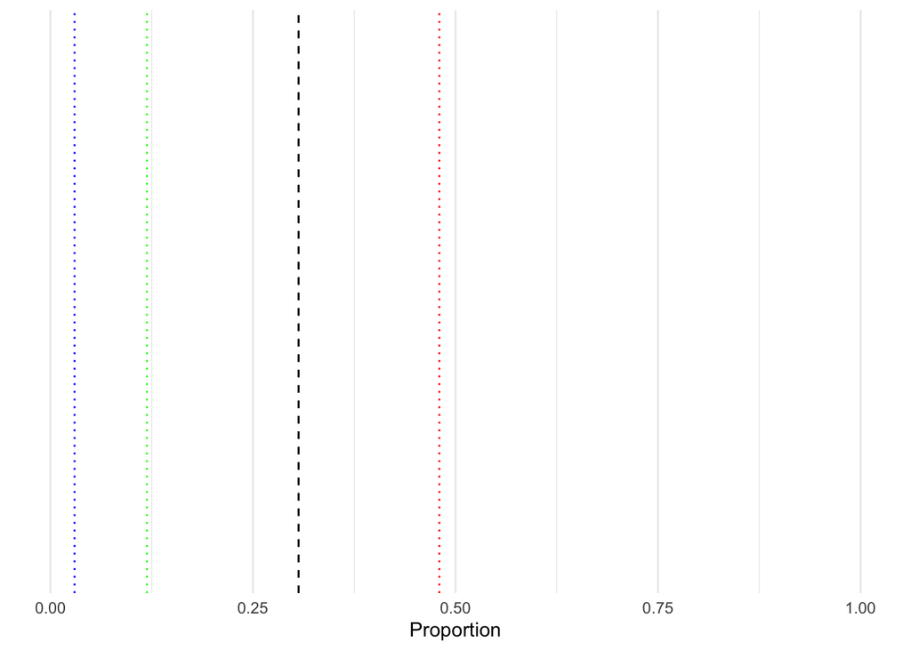

```r
ggplot() +
  coord_cartesian(xlim = c(0,1), ylim = c(0,1)) +
  geom_vline(xintercept = true_prop[2,2][[1]], linetype = "dashed")  +
  geom_vline(xintercept = sample_prop[2,2][[1]], linetype = "dotted", col = "red") +
  geom_vline(xintercept = rep_sample_25[2,2][[1]], linetype = "dotted", col = "blue") +
  geom_vline(xintercept = rep_sample_100[2,2][[1]], linetype = "dotted", col = "green") +
  labs(x = "Proportion")
```

Which one of the two distributions varies more. Can you explain why?

## Question 4

Calculate the standard deviation of your samples collected using a size of 25 and a size of 100.

```r
 rep_sample_25 %>%
 summarize(sd = sd(prop))
```

```
## # A tibble: 1 × 1
##      sd
##   <dbl>
## 1     0
```

```r
rep_sample_100 %>%
summarize(sd = sd(prop))
```

```
## # A tibble: 1 × 1
##      sd
##   <dbl>
## 1     0
```

The standard deviations for both the sample of 25 and sample of 100 is 0 (because all the values are the same in dataset).

Do these results support your argument above? What does this imply about sample size? What happens to the variability in our estimates as the sample size increases?

## Question 5

Now, repeat the same steps above to find the proportion of women who have been awarded the Nobel prize. Draw samples of 100 scientists at a time and plot your distribution of proportions.

```r
nobel_winners_wom <- nobel_winners %>%
  filter(category != "Peace") %>%
  mutate(is_wom = if_else(gender == "Male", 0, 1))
```

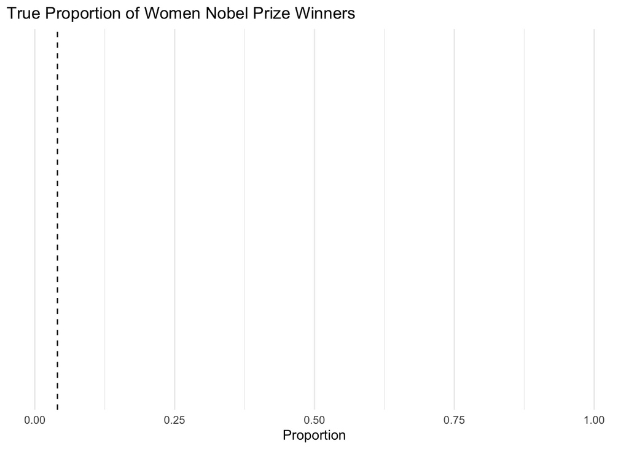

```r
true_wom_prop <- nobel_winners_wom %>%
  group_by(is_wom) %>%
  summarise(prop = n()/nrow(nobel_winners_wom))

ggplot() +
  coord_cartesian(xlim = c(0,1), ylim = c(0,1)) +
  geom_vline(xintercept = true_wom_prop[2,2][[1]], linetype = "dashed")  +
  labs(title = "True Proportion of Women Nobel Prize Winners",
    x = "Proportion")
```

```r
wom_sample_100 <- nobel_winners_wom %>%
rep_sample_n(size = 100,
             reps = 50) %>%
summarise(prop = n()/nrow(nobel_winners_wom))
wom_sample_100
```

```
## # A tibble: 50 × 2
##    replicate  prop
##        <int> <dbl>
##  1         1 0.119
##  2         2 0.119
##  3         3 0.119
##  4         4 0.119
##  5         5 0.119
##  6         6 0.119
##  7         7 0.119
##  8         8 0.119
##  9         9 0.119
## 10        10 0.119
## # ℹ 40 more rows
```

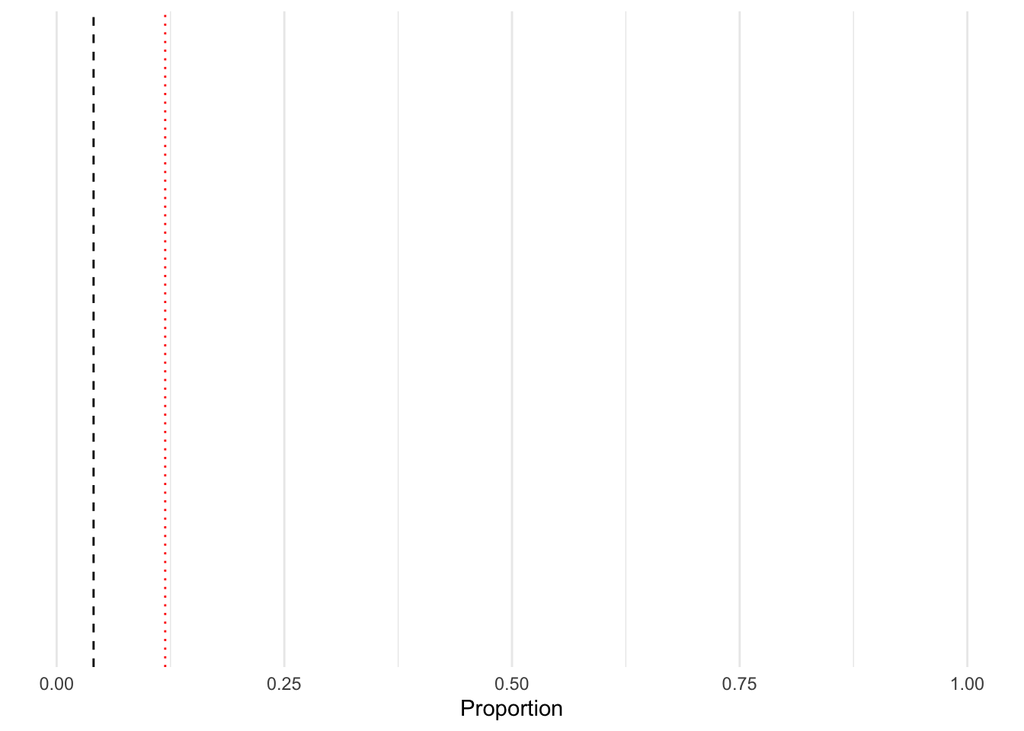

```r
ggplot() +
  coord_cartesian(xlim = c(0,1), ylim = c(0,1)) +
  geom_vline(xintercept = true_wom_prop[2,2][[1]], linetype = "dashed")  +
  geom_vline(xintercept = wom_sample_100[2,2][[1]], linetype = "dotted", col = "red") +
  labs(x = "Proportion")
```

## Question 6

The Central Limit Theorem explains that when your sample size increases, the distribution of averages become more normal (bell shape curve become taller/narrower). It is essential that your sample size is as large as possible because the more data you collect, the more accurate your distribution is to the actual population proportion. This would result in having a more precise distribution (a taller bell/shape curve).